# Week1 LAB: Bayesian Belief Update

#### Minju Jo

```python
import numpy as np
np.set_printoptions(precision=3)
import pandas as pd
pd.set_option('display.precision',3)
import matplotlib.pyplot as plt
```

## Case1: Beta-Bonimal (unknown p)

```python
from scipy.stats import binom, beta
```

### Sampling Density

Every statistical inference or prediction should always start first with the assumption on sampling density , i.e. data generating process. In this case, we have a data set from a classical coin toss, yi∈{0,1} , where yi=1 with a probability p , and our goal is to make Bayesian inference on the parameter p .

```python
# population parameter
p = 0.3
# generate toy sample
N = 15
np.random.seed(101)
data = binom.rvs(1,p, size=N)
print(data)
print(data.size)
print(data.sum())
```

```
[0 0 0 0 0 1 0 1 1 0 0 0 0 1 1]
15
5
```

### Prior Belief

Prior belief can be in any form (flat, peaked, skewed, bimodal...) as long as the belief satistifies the fundamental axioms of probability. We choose beta distribution to express our belief solely because of its analytic convenience, that is, the resulting posterior can be integrated.

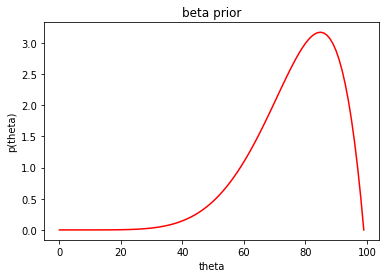

```python
a=7;b=2

prior = beta(a,b)
theta = np.linspace(0,1,100)
plt.plot(prior.pdf(theta),color='r')
plt.title('beta prior')
plt.xlabel('theta')
plt.ylabel('p(theta)')
```

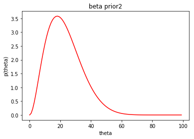

```python
a2= 3; b2= 10

prior2 = beta(a2, b2)
theta = np.linspace(0,1,100)
plt.plot(prior2.pdf(theta), color='r')
plt.title('beta prior2')
plt.xlabel('theta')
plt.ylabel('p(theta)')
```

### Likelihood (Sampling Density)

Once you have specified your belief, you need to consider "how likely" the data is at each point of p . What you would really come in handy is a plot where every possible choice of p is on x-axis and the y-axis shows "how likely the data came from that choice of p . Likelihood does exactly this.

```
(0, 0.0005)
```

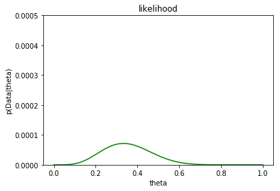

```python
def likelihood(D,p):
    N=D.size
    suc=D.sum()
    theta=np.linspace(0,1,100)
    return p**suc * (1-p)**(N-suc)

plt.plot(theta, likelihood(data, theta), color='g')
plt.title("likelihood")
plt.xlabel("theta")
plt.ylabel("p(Data|theta)")
plt.ylim(0,0.0005)
```

### Posterior: Updated Belief

The posterior is defined by strictly applying Bayes Rule; p(θ|D)=p(θ)p(D|θ)∫p(θ)p(D|θ)dθ . This is in most cases analytically intractable, but in this case where we have a conjugacy between the belief distribution and the sampling distribution, this simply reduces to updating belief paratemers; a, b. Otherwise we have to approximate p(θ|D) or use numerical methods, such as MCMC.

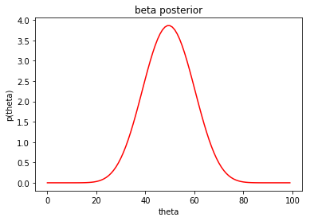

```python
a_pos = a + data.sum()
b_pos = b + data.size - data.sum()

posterior = beta(a_pos, b_pos)
theta = np.linspace(0,1,100)
plt.plot(posterior.pdf(theta), color='r')
plt.title('beta posterior')
plt.xlabel('theta')
plt.ylabel('p(theta)')
```

```
(0, 4)
```

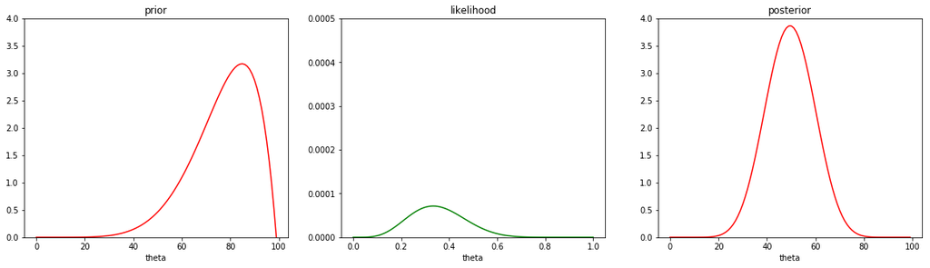

```python
# in a nutshell;
fig = plt.figure(figsize=(20,5))

ax1 = fig.add_subplot(131)
ax1.plot(prior.pdf(theta), color='r')
ax1.set_title('prior')
ax1.set_xlabel('theta')
ax1.set_ylim(0,4)

ax2 = fig.add_subplot(132)
ax2.plot(theta, likelihood(data, theta), color='g')
ax2.set_title('likelihood')
ax2.set_xlabel('theta')
ax2.set_ylim(0,0.0005)

ax3 = fig.add_subplot(133)
ax3.plot(posterior.pdf(theta), color='r')
ax3.set_title('posterior')
ax3.set_xlabel('theta')
ax3.set_ylim(0,4)
```

```python
from scipy.stats import norm, describe
```

### Sampling Density

```python
# population parameter
mu = 30
sig = 2
# generate toy sample
N = 20
np.random.seed(48)
data = norm.rvs(mu, sig, size=N)
print(data)
print(describe(data))
```

```
[28.013 27.873 28.724 32.123 29.685 32.187 25.85  31.401 33.349 29.205
 34.648 28.001 28.882 25.993 29.268 27.487 34.082 31.191 33.118 33.692]
DescribeResult(nobs=20, minmax=(25.850291962908912, 34.64759389217308), mean=30.238581489438992, variance=7.398178463355905, skewness=0.07690268916347295, kurtosis=-1.2033825284958215)
```

### Priror on mu

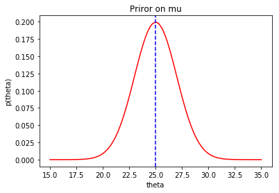

```python
mu1=25; sd1=2
prior = norm(mu1,sd1)
theta = np.linspace(15,35,100)

plt.plot(theta,prior.pdf(theta),color='r')
plt.title('Priror on mu')
plt.axvline(25, color = 'b', linestyle = '--')
plt.xlabel('theta')
plt.ylabel('p(theta)')
```

### Log Likelihood (Sampling Density)

```python
def lll(x,mu,sd):
    return np.log(norm.pdf(x, mu, sd))
```

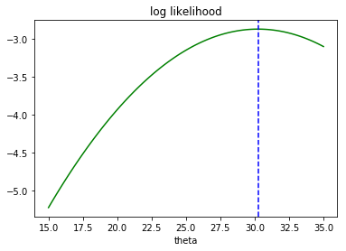

```python
plt.plot(theta, lll(theta, np.mean(data), np.var(data)), color='g')
plt.title("log likelihood")
plt.xlabel("theta")
plt.axvline(np.mean(data), color = 'b', linestyle = '--')
```

### Posterior on mu

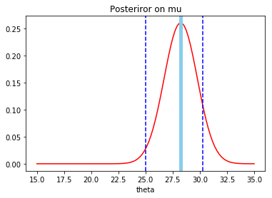

```python
d_mean=np.mean(data)
d_sd=np.var(data)

post_mu = (mu1 * (1/ sd1**2) + d_mean * (N/d_sd**2))/ (1/sd1**2 + N/d_sd**2)
post_sd = 1/((1/ sd1**2)+ N/d_sd**2)

post = norm(post_mu, post_sd)
plt.plot(theta, post.pdf(theta), color= 'r')
plt.title("Posteriror on mu")
plt.xlabel("theta")
plt.axvline(np.mean(data), color = 'b', linestyle = '--')
plt.axvline(mu1, color = 'b', linestyle = '--')
plt.axvline(post_mu, color = 'skyblue', linestyle = '-',linewidth=5)
```

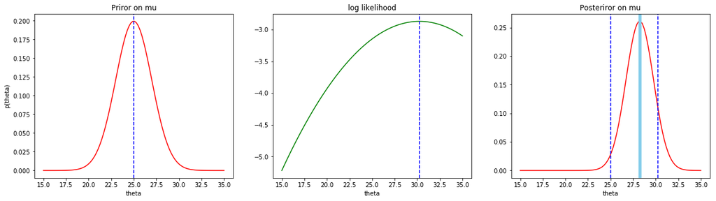

```python
fig = plt.figure(figsize=(20,5))

ax1 = fig.add_subplot(131)
ax1.plot(theta,prior.pdf(theta),color='r')
ax1.set_title('Priror on mu')
ax1.set_xlabel('theta')
ax1.set_ylabel('p(theta)')
plt.axvline(25, color = 'b', linestyle = '--')

ax2 = fig.add_subplot(132)
ax2.plot(theta, lll(theta, np.mean(data), np.var(data)), color='g')
ax2.set_title("log likelihood")
ax2.set_xlabel("theta")
plt.axvline(np.mean(data), color = 'b', linestyle = '--')

ax3 = fig.add_subplot(133)
ax3.plot(theta, post.pdf(theta), color= 'r')
ax3.set_title("Posteriror on mu")
ax3.set_xlabel("theta")
plt.axvline(np.mean(data), color = 'b', linestyle = '--')
plt.axvline(mu1, color = 'b', linestyle = '--')
plt.axvline(post_mu, color = 'skyblue', linestyle = '-',linewidth=5)
```